# Regressions

2024-12-07

# Regressions

Cleaning environment

```r
rm(list = ls())
```

# Inputting data and loading packages

```r
library(plm)
library(zoo)
library(lmtest)
library(car)
```

```r
library(ggplot2)
library(dynlm)
library(stargazer)
data <- read.csv("C:/Users/Stanislav/OneDrive/Pulpit/Szwajcaria/Studies/Smart Data Analysis for Financial Assets/Project/Project_data.csv")
data$Date <- as.Date(data$Date, format = '%d/%m/%Y')
attach(data)
```

# First models

```r
model1 <- lm(log(Bitcoin_Price) ~ OECD_GDP_Change + log(Gold_Price) + OECD_CPI + log(WM2NS) + VIX)
summary(model1)
```

```
##
## Call:
## lm(formula = log(Bitcoin_Price) ~ OECD_GDP_Change + log(Gold_Price) +
##     OECD_CPI + log(WM2NS) + VIX)
##
## Residuals:
##     Min      1Q  Median      3Q     Max
## -1.2779 -0.4996 -0.1177  0.4131  1.6142
##
## Coefficients:
##                   Estimate Std. Error t value Pr(>|t|)
## (Intercept)     -80.893372   6.887303 -11.745 1.07e-14 ***
## OECD_GDP_Change  -0.008924   0.054825  -0.163   0.8715
## log(Gold_Price)  -4.074857   0.838047  -4.862 1.74e-05 ***
## OECD_CPI         -0.166416   0.061961  -2.686   0.0104 *
## log(WM2NS)       12.459730   0.691879  18.009  < 2e-16 ***
## VIX              -0.040701   0.017250  -2.359   0.0231 *
## ---
## Signif. codes:  0 '***' 0.001 '**' 0.01 '*' 0.05 '.' 0.1 ' ' 1
##
## Residual standard error: 0.7586 on 41 degrees of freedom
## Multiple R-squared:  0.9191, Adjusted R-squared:  0.9092
## F-statistic: 93.13 on 5 and 41 DF,  p-value: < 2.2e-16
```

```r
model2 <- lm(log(Bitcoin_Price) ~  log(Gold_Price) + OECD_CPI + log(WM2NS) + VIX)
summary(model2)
```

```
##
## Call:
## lm(formula = log(Bitcoin_Price) ~ log(Gold_Price) + OECD_CPI +
##     log(WM2NS) + VIX)
##
## Residuals:
##     Min      1Q  Median      3Q     Max
## -1.2780 -0.5045 -0.1113  0.4141  1.6152
##
## Coefficients:
##                  Estimate Std. Error t value Pr(>|t|)
## (Intercept)     -80.81143    6.78881 -11.904 4.82e-15 ***
## log(Gold_Price)  -4.07671    0.82820  -4.922 1.37e-05 ***
## OECD_CPI         -0.16632    0.06124  -2.716  0.00955 **
## log(WM2NS)       12.45087    0.68169  18.265  < 2e-16 ***
## VIX              -0.04006    0.01659  -2.414  0.02022 *
## ---
## Signif. codes:  0 '***' 0.001 '**' 0.01 '*' 0.05 '.' 0.1 ' ' 1
##
## Residual standard error: 0.7498 on 42 degrees of freedom
## Multiple R-squared:  0.919,  Adjusted R-squared:  0.9113
## F-statistic: 119.2 on 4 and 42 DF,  p-value: < 2.2e-16
```

# Checking time properties and relationships

## Quarterly dummies

```r
quarter <- as.integer(format(Date, "%m")) %/% 3
quarter_dummies <- factor(quarter, levels = 1:4, labels = c("Q1", "Q2", "Q3", "Q4"))

model_dummy <- lm(log(Bitcoin_Price) ~ log(Gold_Price) + OECD_CPI + log(WM2NS) + VIX + quarter_dummies)
summary(model_dummy)
```

```
##
## Call:
## lm(formula = log(Bitcoin_Price) ~ log(Gold_Price) + OECD_CPI +
##     log(WM2NS) + VIX + quarter_dummies)
##
## Residuals:
##     Min      1Q  Median      3Q     Max
## -1.2217 -0.4862 -0.1510  0.4337  1.6746
##
## Coefficients:
##                    Estimate Std. Error t value Pr(>|t|)
## (Intercept)       -80.73631    7.03648 -11.474 4.53e-14 ***
## log(Gold_Price)    -4.11590    0.86479  -4.759 2.67e-05 ***
## OECD_CPI           -0.16642    0.06345  -2.623   0.0124 *
## log(WM2NS)         12.47840    0.71061  17.560  < 2e-16 ***
## VIX                -0.04035    0.01727  -2.336   0.0247 *
## quarter_dummiesQ2  -0.02418    0.31859  -0.076   0.9399
## quarter_dummiesQ3  -0.05979    0.31802  -0.188   0.8518
## quarter_dummiesQ4  -0.11252    0.32816  -0.343   0.7335
## ---
## Signif. codes:  0 '***' 0.001 '**' 0.01 '*' 0.05 '.' 0.1 ' ' 1
##
## Residual standard error: 0.7768 on 39 degrees of freedom
## Multiple R-squared:  0.9193, Adjusted R-squared:  0.9048
## F-statistic: 63.47 on 7 and 39 DF,  p-value: < 2.2e-16
```

There seems to be no seasonality - all dummy variables are statistically insignificant.

## Adding time trend to de-trend the data

```r
trend <- as.numeric(as.yearqtr(Date))
model_trend <- lm(log(Bitcoin_Price) ~ log(Gold_Price) + OECD_CPI + log(WM2NS) + VIX + trend)
summary(model_trend)
```

```
##
## Call:
## lm(formula = log(Bitcoin_Price) ~ log(Gold_Price) + OECD_CPI +
##     log(WM2NS) + VIX + trend)
##
## Residuals:
##      Min       1Q   Median       3Q      Max
## -1.05476 -0.56290  0.00503  0.46211  1.51532
##
## Coefficients:
##                   Estimate Std. Error t value Pr(>|t|)
## (Intercept)     -857.06303  303.39952  -2.825 0.007273 **
## log(Gold_Price)   -3.16840    0.85548  -3.704 0.000627 ***
## OECD_CPI          -0.16744    0.05755  -2.909 0.005828 **
## log(WM2NS)         6.63965    2.35947   2.814 0.007481 **
## VIX               -0.03565    0.01569  -2.272 0.028371 *
## trend              0.40899    0.15982   2.559 0.014282 *
## ---
## Signif. codes:  0 '***' 0.001 '**' 0.01 '*' 0.05 '.' 0.1 ' ' 1
##
## Residual standard error: 0.7047 on 41 degrees of freedom
## Multiple R-squared:  0.9302, Adjusted R-squared:  0.9217
## F-statistic: 109.2 on 5 and 41 DF,  p-value: < 2.2e-16
```

## Autocorrelation test

```r
bgtest(model2, order = 1)
```

```
##
##  Breusch-Godfrey test for serial correlation of order up to 1
##
## data:  model2
## LM test = 18.701, df = 1, p-value = 1.529e-05
```

## Adding lags on Bitcoin_Price

```r
model3 <- lm(log(Bitcoin_Price) ~  lag(log(Bitcoin_Price), 1) + log(Gold_Price) + OECD_CPI + log(WM2NS) + VIX)
summary(model3)
```

```
##
## Call:
## lm(formula = log(Bitcoin_Price) ~ lag(log(Bitcoin_Price), 1) +
##     log(Gold_Price) + OECD_CPI + log(WM2NS) + VIX)
##
## Residuals:
##        Min         1Q     Median         3Q        Max
## -1.194e-15 -1.415e-16 -6.239e-17  9.177e-17  3.122e-15
##
## Coefficients:
##                              Estimate Std. Error    t value Pr(>|t|)
## (Intercept)                -1.036e-15  1.062e-14 -9.800e-02    0.923
## lag(log(Bitcoin_Price), 1)  1.000e+00  1.154e-16  8.664e+15   <2e-16 ***
## log(Gold_Price)             4.586e-16  7.780e-16  5.900e-01    0.559
## OECD_CPI                    8.837e-18  4.967e-17  1.780e-01    0.860
## log(WM2NS)                 -3.632e-17  1.525e-15 -2.400e-02    0.981
## VIX                        -2.313e-18  1.325e-17 -1.750e-01    0.862
## ---
## Signif. codes:  0 '***' 0.001 '**' 0.01 '*' 0.05 '.' 0.1 ' ' 1
##
## Residual standard error: 5.609e-16 on 41 degrees of freedom
## Multiple R-squared:      1,  Adjusted R-squared:      1
## F-statistic: 1.854e+32 on 5 and 41 DF,  p-value: < 2.2e-16
```

Effect of adding lagged log(Bitcoin_Prices) is surprising - adjusted R-squared equals 1, showing near perfect fit. That means, that prices of Bitcoin from the past have far stronger influence on today prices than any other variable. To adress that problem, the structure of the model is to be changed to First Differences, allowing to explore the relationship between other variables and Bitcoin_Prices.

## Changing model specification to First Differences

```r
data$diff_log_Bitcoin_Price <- c(NA, diff(log(data$Bitcoin_Price)))
data$diff_log_Gold_Price <- c(NA, diff(log(data$Gold_Price)))
data$diff_log_WM2NS <- c(NA, diff(log(data$WM2NS)))
data$diff_OECD_CPI <- c(NA, diff(data$OECD_CPI))
data$diff_VIX <- c(NA, diff(data$VIX))
attach(data)
```

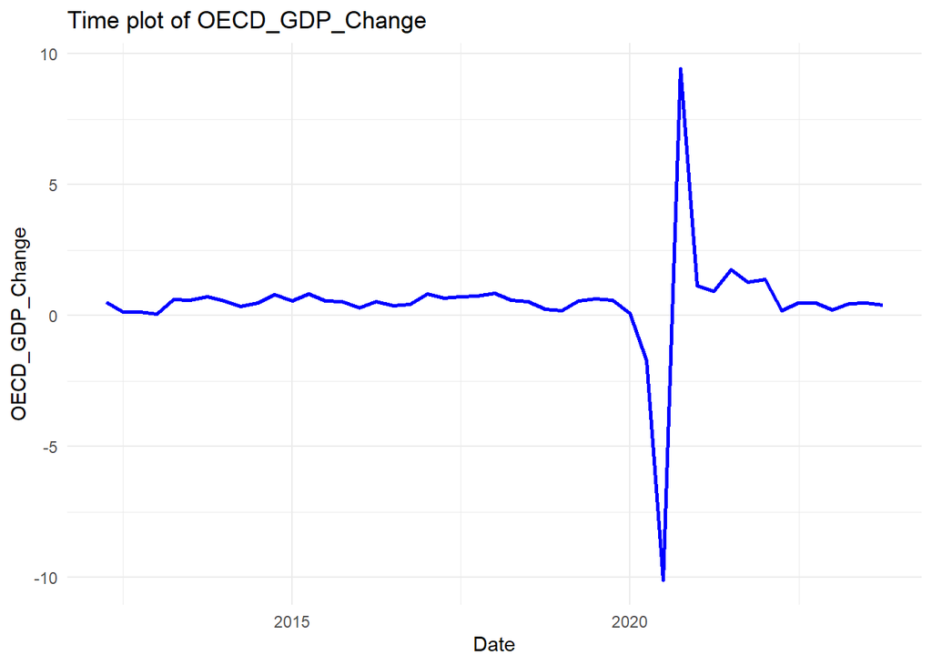

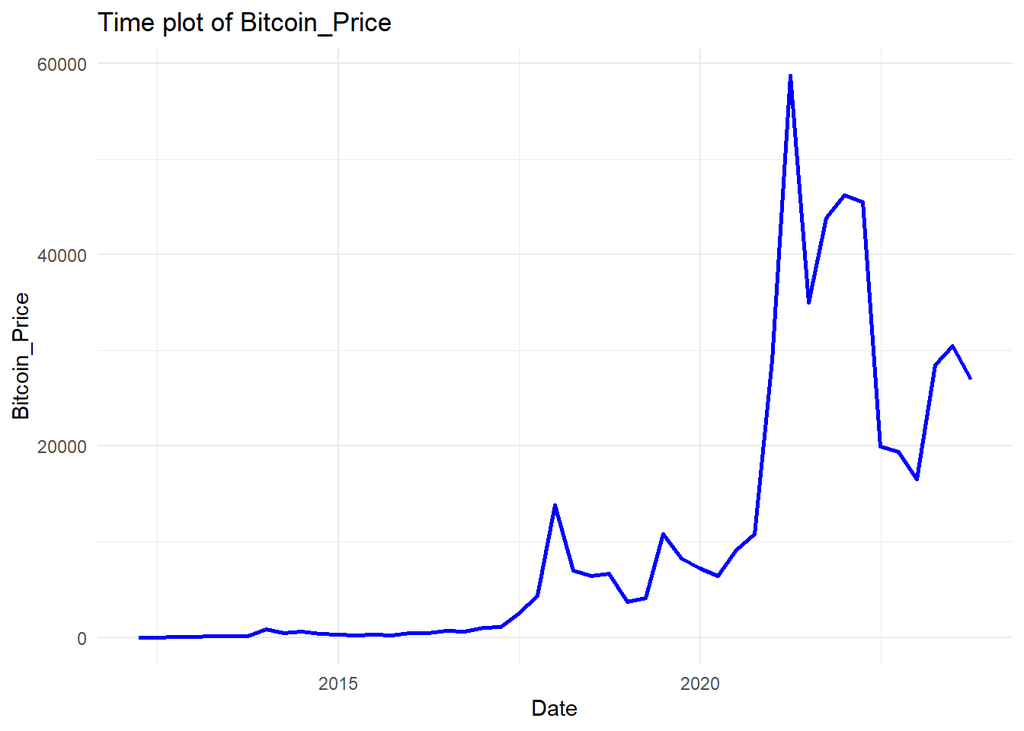

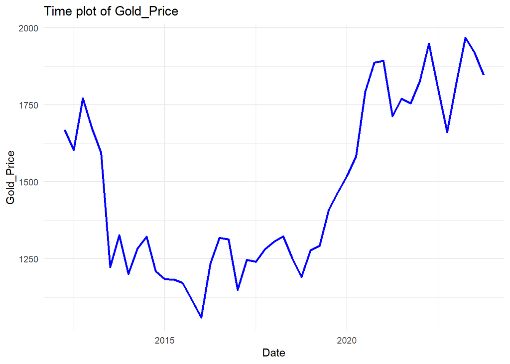

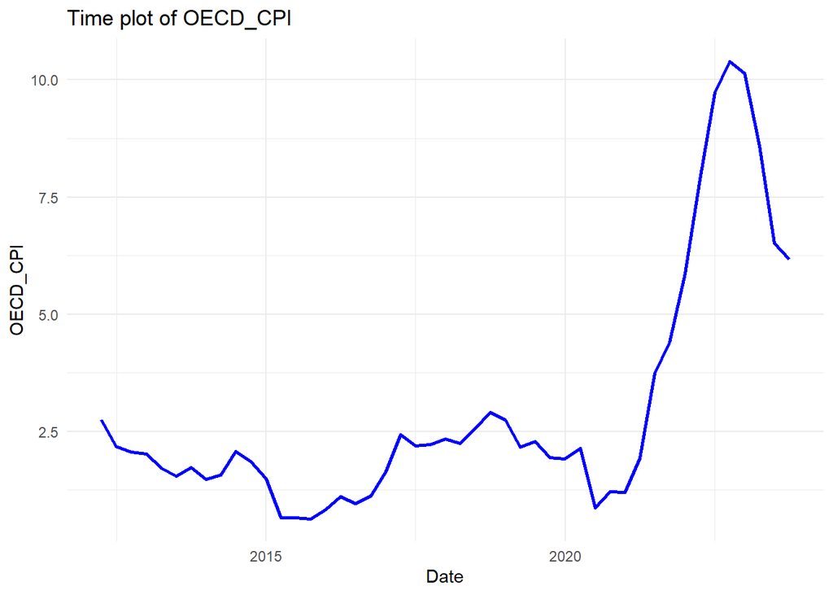

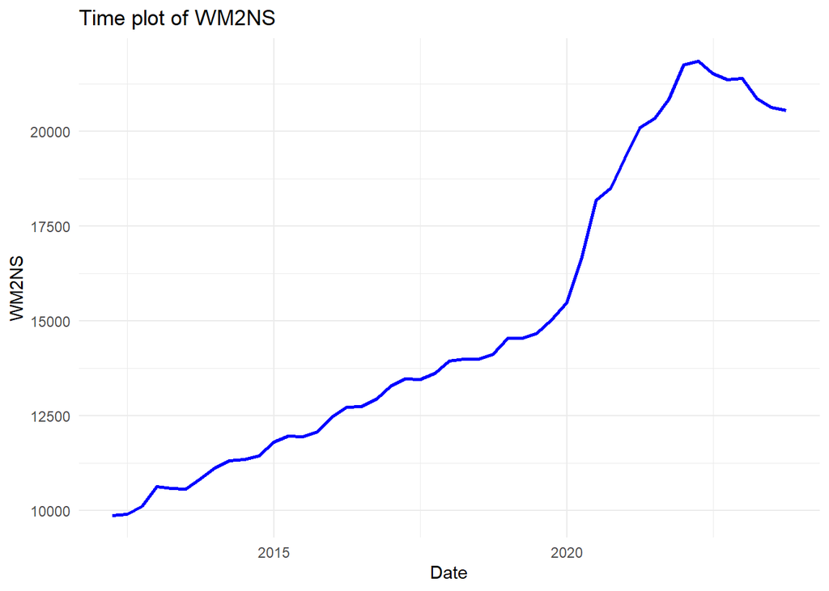

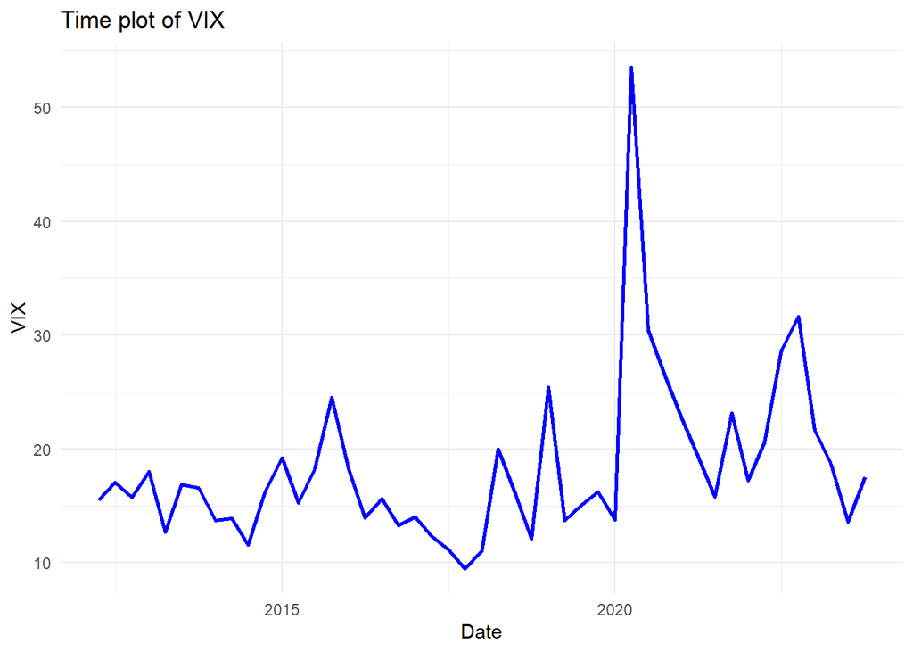

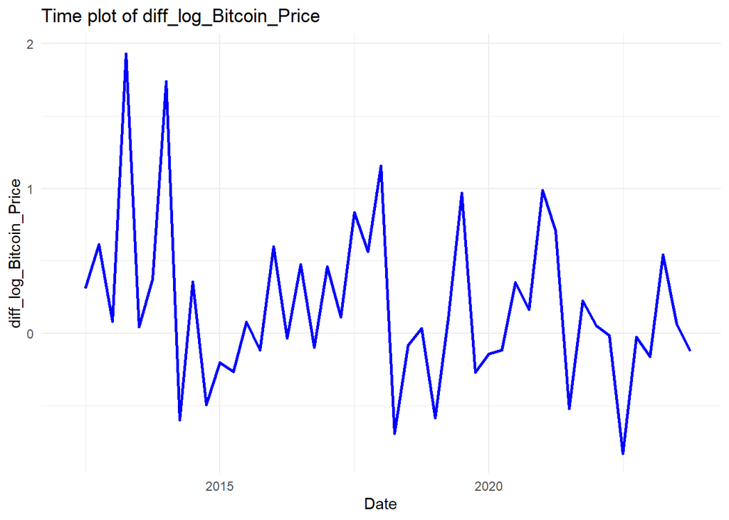

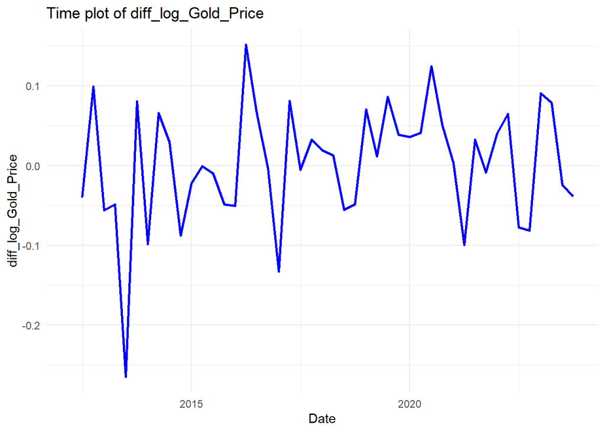

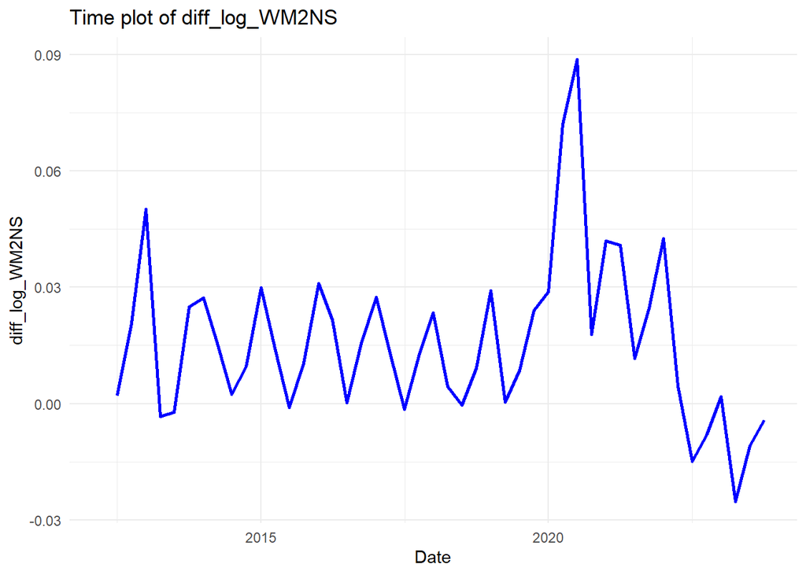

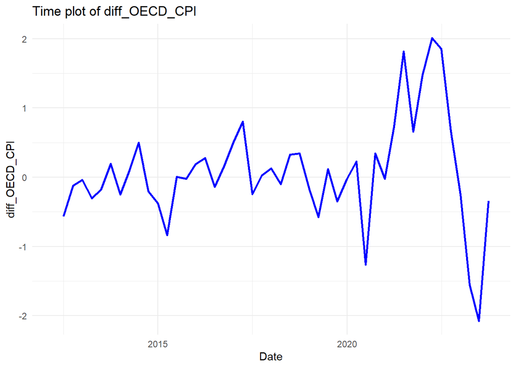

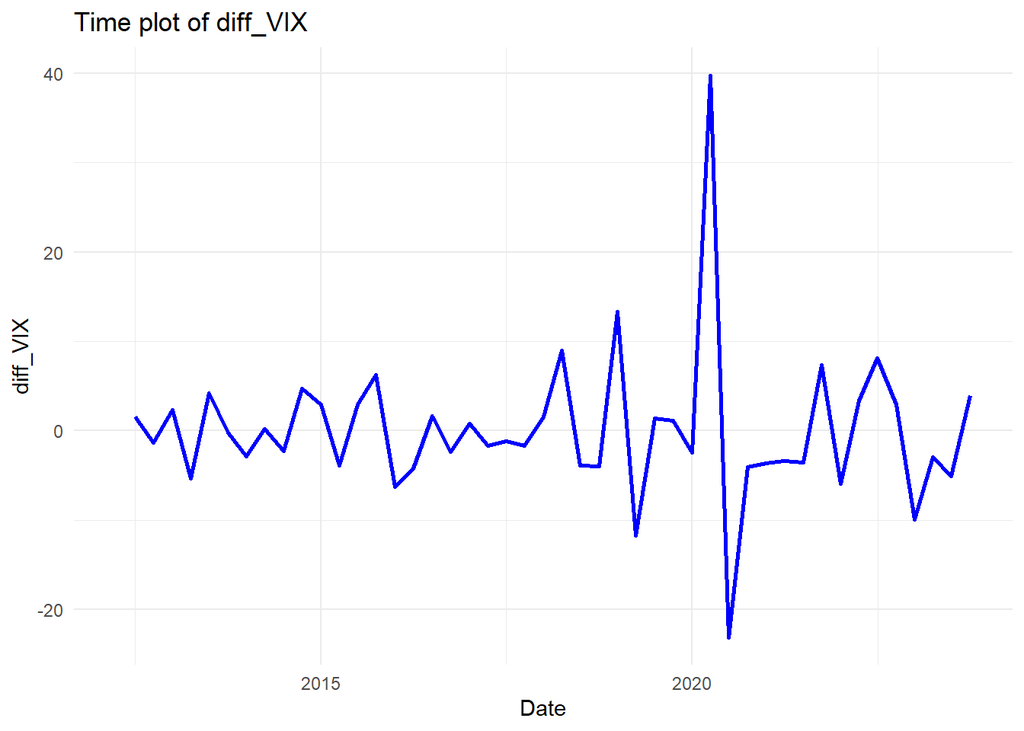

```r
 for (column in colnames(data)){

if (is.numeric(data[[column]])){

plot <- ggplot(data, aes(x=Date, y=data[[column]]))+ geom_line(color = 'blue', linewidth =1)+
  ggtitle(paste('Time plot of', column))+ ylab(column)+ xlab("Date")+ theme_minimal()
print(plot)
}
}
```

```r
model_fd <- dynlm(diff_log_Bitcoin_Price ~ L(diff_log_Bitcoin_Price,1) + diff_log_Gold_Price + diff_OECD_CPI + diff_log_WM2NS + diff_VIX)
summary(model_fd)
```

```
##
## Time series regression with "numeric" data:
## Start = 1, End = 46
##
## Call:
## dynlm(formula = diff_log_Bitcoin_Price ~ L(diff_log_Bitcoin_Price,
##     1) + diff_log_Gold_Price + diff_OECD_CPI + diff_log_WM2NS +
##     diff_VIX)
##
## Residuals:
##        Min         1Q     Median         3Q        Max
## -9.205e-17 -2.603e-17 -9.330e-18  2.970e-18  5.189e-16
##
## Coefficients:
##                                Estimate Std. Error    t value Pr(>|t|)
## (Intercept)                  -3.274e-17  1.684e-17 -1.944e+00   0.0589 .
## L(diff_log_Bitcoin_Price, 1)  1.000e+00  2.470e-17  4.048e+16   <2e-16 ***
## diff_log_Gold_Price           2.749e-16  1.807e-16  1.521e+00   0.1362
## diff_OECD_CPI                 2.873e-18  1.787e-17  1.610e-01   0.8731
## diff_log_WM2NS               -2.466e-16  6.399e-16 -3.850e-01   0.7020
## diff_VIX                      6.710e-19  1.693e-18  3.960e-01   0.6940
## ---
## Signif. codes:  0 '***' 0.001 '**' 0.01 '*' 0.05 '.' 0.1 ' ' 1
##
## Residual standard error: 8.843e-17 on 40 degrees of freedom
##   (1 observation deleted due to missingness)
## Multiple R-squared:      1,  Adjusted R-squared:      1
## F-statistic: 3.742e+32 on 5 and 40 DF,  p-value: < 2.2e-16
```

Same problem - near perfect fit.

```r
dwtest(model_fd)
```

```
##
##  Durbin-Watson test
##
## data:  model_fd
## DW = 2.2252, p-value = 0.7606
## alternative hypothesis: true autocorrelation is greater than 0
```

```r
library(prais)
model_prais <- prais_winsten(log(Bitcoin_Price) ~ lag(log(Bitcoin_Price), 1) + log(Gold_Price) + OECD_CPI + log(WM2NS) + VIX, data = data, index = 'Date')
```

```
## Iteration 0: rho = 0
## Iteration 1: rho = -0.3607
## Iteration 2: rho = 0.9615
## Iteration 3: rho = 0.9156
## Iteration 4: rho = 0.75
## Iteration 5: rho = 0.999
## Iteration 6: rho = 0.9708
## Iteration 7: rho = 0.7903
## Iteration 8: rho = 0.8863
## Iteration 9: rho = 0.8333
## Iteration 10: rho = 0.8333
```

```r
summary(model_prais)
```

```
##
## Call:
## prais_winsten(formula = log(Bitcoin_Price) ~ lag(log(Bitcoin_Price),
##     1) + log(Gold_Price) + OECD_CPI + log(WM2NS) + VIX, data = data,
##     index = "Date")
##
## Residuals:
##        Min         1Q     Median         3Q        Max
## -4.441e-16  0.000e+00  0.000e+00  0.000e+00  0.000e+00
##
## AR(1) coefficient rho after 10 iterations: 0.8333
##
## Coefficients:
##                              Estimate Std. Error    t value Pr(>|t|)
## (Intercept)                 0.000e+00  2.398e-15  0.000e+00    1.000
## lag(log(Bitcoin_Price), 1)  1.000e+00  1.878e-17  5.325e+16   <2e-16 ***
## log(Gold_Price)            -1.254e-16  1.408e-16 -8.910e-01    0.378
## OECD_CPI                    1.143e-17  1.324e-17  8.640e-01    0.393
## log(WM2NS)                  1.210e-16  2.804e-16  4.310e-01    0.668
## VIX                         2.466e-19  1.384e-18  1.780e-01    0.859
## ---
## Signif. codes:  0 '***' 0.001 '**' 0.01 '*' 0.05 '.' 0.1 ' ' 1
##
## Residual standard error: 6.715e-17 on 41 degrees of freedom
## Multiple R-squared:      1,  Adjusted R-squared:      1
## F-statistic: 6.86e+32 on 5 and 41 DF,  p-value: < 2.2e-16
##
## Durbin-Watson statistic (original): 2.599
## Durbin-Watson statistic (transformed): 1.267
```

# Regression specification error test - RESET test

```r
resettest(model_trend)
```

```
##
##  RESET test
##
## data:  model_trend
## RESET = 3.3457, df1 = 2, df2 = 39, p-value = 0.0456
```

# Collinearity test - Variation Inflation Factor

```r
vif(model2)
```

```
## log(Gold_Price)        OECD_CPI      log(WM2NS)             VIX
##        1.930988        2.063353        2.506482        1.204473
```

```r
vif(model_trend)
```

```
## log(Gold_Price)        OECD_CPI      log(WM2NS)             VIX           trend
##        2.332502        2.063472       33.994328        1.219123       27.801238
```

Variation Inflation Factor shows values significantly higher than 10 for trend and log(WM2NS) in model with time trend. This shows high collinearity with global liquidity (log(WM2NS)), what implies that much of time trend is already included in liquidity. Analysis of time plot of global liquidity supports this conclusion. Therefore trend is not to be included and another method to include time trend is to be used.

```r
stargazer(model2, model3, model_fd)
```

```
##
## % Table created by stargazer v.5.2.3 by Marek Hlavac, Social Policy Institute. E-mail: marek.hlavac at gmail.com
## % Date and time: Mon, Dec 09, 2024 - 14:28:40
## \begin{table}[!htbp] \centering
##   \caption{}
##   \label{}
## \begin{tabular}{@{\extracolsep{5pt}}lccc}
## \\[-1.8ex]\hline
## \hline \\[-1.8ex]
##  & \multicolumn{3}{c}{\textit{Dependent variable:}} \\
## \cline{2-4}
## \\[-1.8ex] & \multicolumn{2}{c}{log(Bitcoin\_Price)} & diff\_log\_Bitcoin\_Price \\
## \\[-1.8ex] & \multicolumn{2}{c}{\textit{OLS}} & \textit{dynamic} \\
##  & \multicolumn{2}{c}{\textit{}} & \textit{linear} \\
## \\[-1.8ex] & (1) & (2) & (3)\\
## \hline \\[-1.8ex]
##  lag(log(Bitcoin\_Price), 1) &  & 1.000$^{***}$ &  \\
##   &  & (0.000) &  \\
##   & & & \\
##  log(Gold\_Price) & $-$4.077$^{***}$ & 0.000 &  \\
##   & (0.828) & (0.000) &  \\
##   & & & \\
##  OECD\_CPI & $-$0.166$^{***}$ & 0.000 &  \\
##   & (0.061) & (0.000) &  \\
##   & & & \\
##  log(WM2NS) & 12.451$^{***}$ & $-$0.000 &  \\
##   & (0.682) & (0.000) &  \\
##   & & & \\
##  VIX & $-$0.040$^{**}$ & $-$0.000 &  \\
##   & (0.017) & (0.000) &  \\
##   & & & \\
##  L(diff\_log\_Bitcoin\_Price, 1) &  &  & 1.000$^{***}$ \\
##   &  &  & (0.000) \\
##   & & & \\
##  diff\_log\_Gold\_Price &  &  & 0.000 \\
##   &  &  & (0.000) \\
##   & & & \\
##  diff\_OECD\_CPI &  &  & 0.000 \\
##   &  &  & (0.000) \\
##   & & & \\
##  diff\_log\_WM2NS &  &  & $-$0.000 \\
##   &  &  & (0.000) \\
##   & & & \\
##  diff\_VIX &  &  & 0.000 \\
##   &  &  & (0.000) \\
##   & & & \\
##  Constant & $-$80.811$^{***}$ & $-$0.000 & $-$0.000$^{*}$ \\
##   & (6.789) & (0.000) & (0.000) \\
##   & & & \\
## \hline \\[-1.8ex]
## Observations & 47 & 47 & 46 \\
## R$^{2}$ & 0.919 & 1.000 & 1.000 \\
## Adjusted R$^{2}$ & 0.911 & 1.000 & 1.000 \\
## Residual Std. Error & 0.750 (df = 42) & 0.000 (df = 41) & 0.000 (df = 40) \\
## F Statistic & 119.170$^{***}$ (df = 4; 42) & 185,389,489,368,963,031,162,248,826,284,808.000$^{***}$ (df = 5; 41) & 374,239,238,615,967,427,722,664,006,444,468.000$^{***}$ (df = 5; 40) \\
## \hline
## \hline \\[-1.8ex]
## \textit{Note:}  & \multicolumn{3}{r}{$^{*}$p$<$0.1; $^{**}$p$<$0.05; $^{***}$p$<$0.01} \\
## \end{tabular}
## \end{table}
```